# Exloratory Data Analysis of White wine Quality by Alina Bolat

In this analysis I will try to determine which of the provided wine characteristics may affect a quality rating.

**Source**: This dataset is available for public research and education purposes. P. Cortez, A. Cerdeira, F. Almeida, T. Matos and J. Reis. Modeling wine preferences by data mining from physicochemical properties. In Decision Support Systems, Elsevier, 47(4):547-553. ISSN: 0167-9236.

```
##        X        fixed.acidity    volatile.acidity  citric.acid
##  Min.   :   1   Min.   : 3.800   Min.   :0.0800   Min.   :0.0000
##  1st Qu.:1225   1st Qu.: 6.300   1st Qu.:0.2100   1st Qu.:0.2700
##  Median :2450   Median : 6.800   Median :0.2600   Median :0.3200
##  Mean   :2450   Mean   : 6.855   Mean   :0.2782   Mean   :0.3342
##  3rd Qu.:3674   3rd Qu.: 7.300   3rd Qu.:0.3200   3rd Qu.:0.3900
##  Max.   :4898   Max.   :14.200   Max.   :1.1000   Max.   :1.6600
##  residual.sugar     chlorides       free.sulfur.dioxide
##  Min.   : 0.600   Min.   :0.00900   Min.   :  2.00
##  1st Qu.: 1.700   1st Qu.:0.03600   1st Qu.: 23.00
##  Median : 5.200   Median :0.04300   Median : 34.00
##  Mean   : 6.391   Mean   :0.04577   Mean   : 35.31
##  3rd Qu.: 9.900   3rd Qu.:0.05000   3rd Qu.: 46.00
##  Max.   :65.800   Max.   :0.34600   Max.   :289.00
##  total.sulfur.dioxide    density             pH          sulphates
##  Min.   :  9.0        Min.   :0.9871   Min.   :2.720   Min.   :0.2200
##  1st Qu.:108.0        1st Qu.:0.9917   1st Qu.:3.090   1st Qu.:0.4100
##  Median :134.0        Median :0.9937   Median :3.180   Median :0.4700
##  Mean   :138.4        Mean   :0.9940   Mean   :3.188   Mean   :0.4898
##  3rd Qu.:167.0        3rd Qu.:0.9961   3rd Qu.:3.280   3rd Qu.:0.5500
##  Max.   :440.0        Max.   :1.0390   Max.   :3.820   Max.   :1.0800
##     alcohol         quality
##  Min.   : 8.00   Min.   :3.000
##  1st Qu.: 9.50   1st Qu.:5.000
##  Median :10.40   Median :6.000
##  Mean   :10.51   Mean   :5.878
##  3rd Qu.:11.40   3rd Qu.:6.000
##  Max.   :14.20   Max.   :9.000
```

# Univariate Plots Section

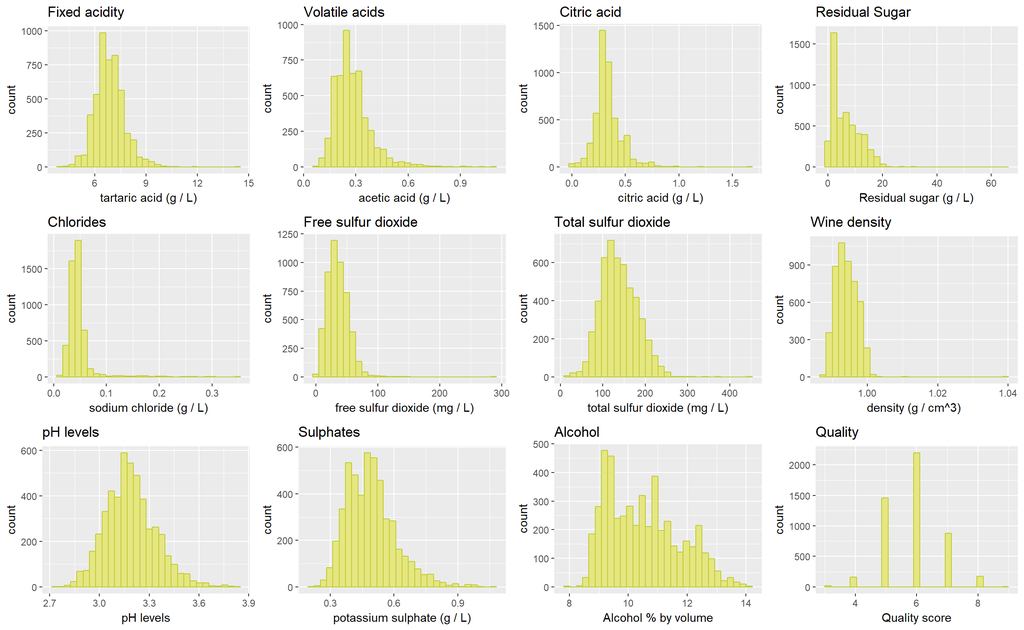

### Acidity

```
##    Min. 1st Qu.  Median    Mean 3rd Qu.    Max.
##   3.800   6.300   6.800   6.855   7.300  14.200
```

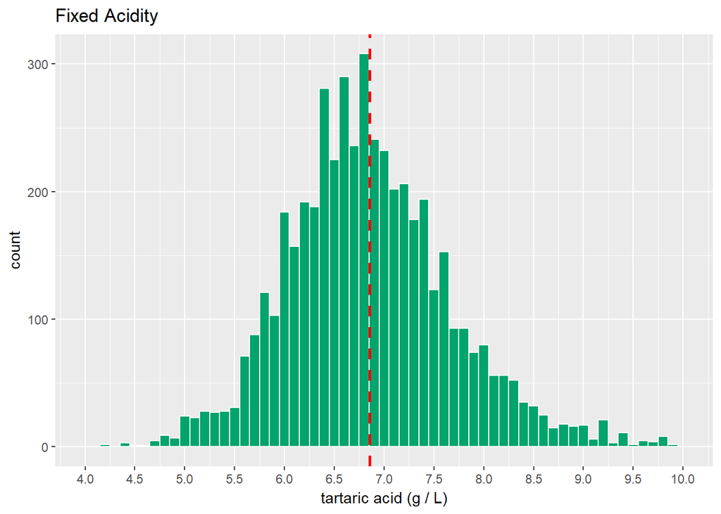

```
##    Min. 1st Qu.  Median    Mean 3rd Qu.    Max.
##  0.0800  0.2100  0.2600  0.2782  0.3200  1.1000
```

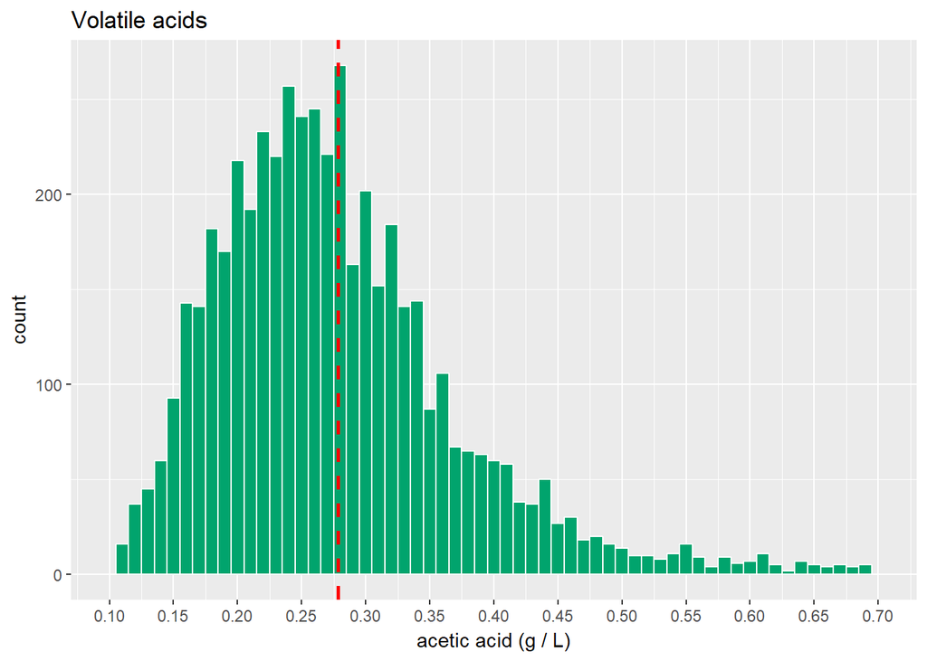

```
##    Min. 1st Qu.  Median    Mean 3rd Qu.    Max.
##  0.0000  0.2700  0.3200  0.3342  0.3900  1.6600
```

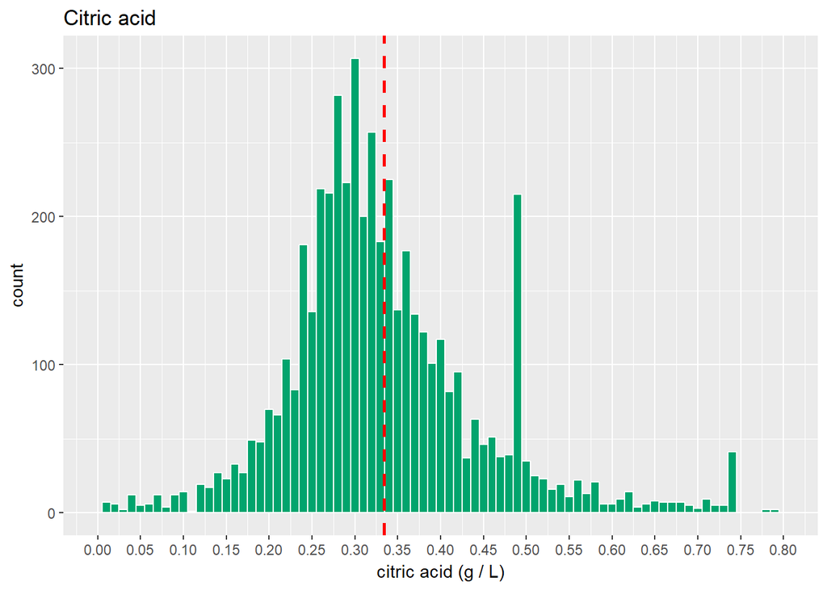

### Residual sugar

```
##    Min. 1st Qu.  Median    Mean 3rd Qu.    Max.
##   0.600   1.700   5.200   6.391   9.900  65.800
```

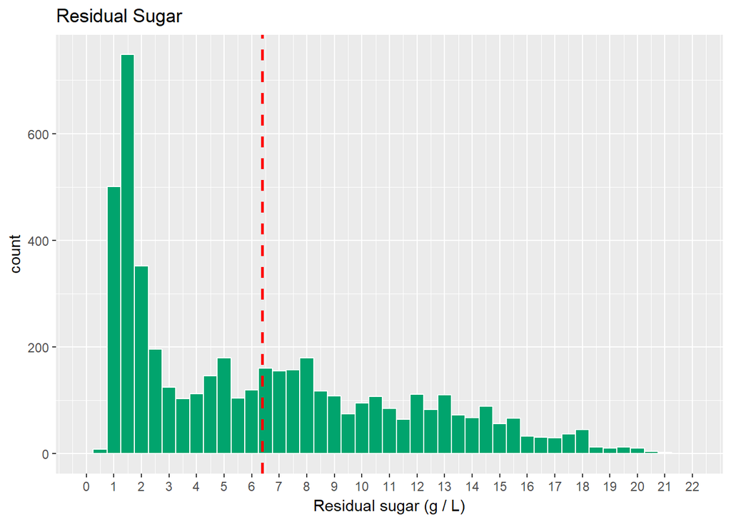

**Residual Sugar** has a binomial distribution when transformed using log10. This may suggest that there are wines which are not sweet at all and those which are pretty sweet, although White wines are considered to be of a dry type.

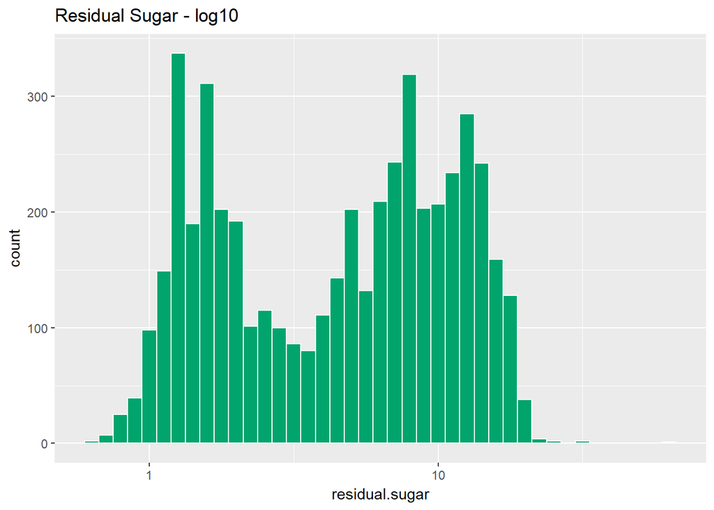

### Chlorides

Chlorides indicate the amount of salt in the wine. There is very little amount of salt in all the wines in this sample. The data follows normal right skewed distribution with the mean at 0.046 mg/L, and the wide spread of 0.01 to 0.35 mg/L. There are many outliers so the plot’s x axis was limited for a better representation.

```
##    Min. 1st Qu.  Median    Mean 3rd Qu.    Max.
## 0.00900 0.03600 0.04300 0.04577 0.05000 0.34600
```

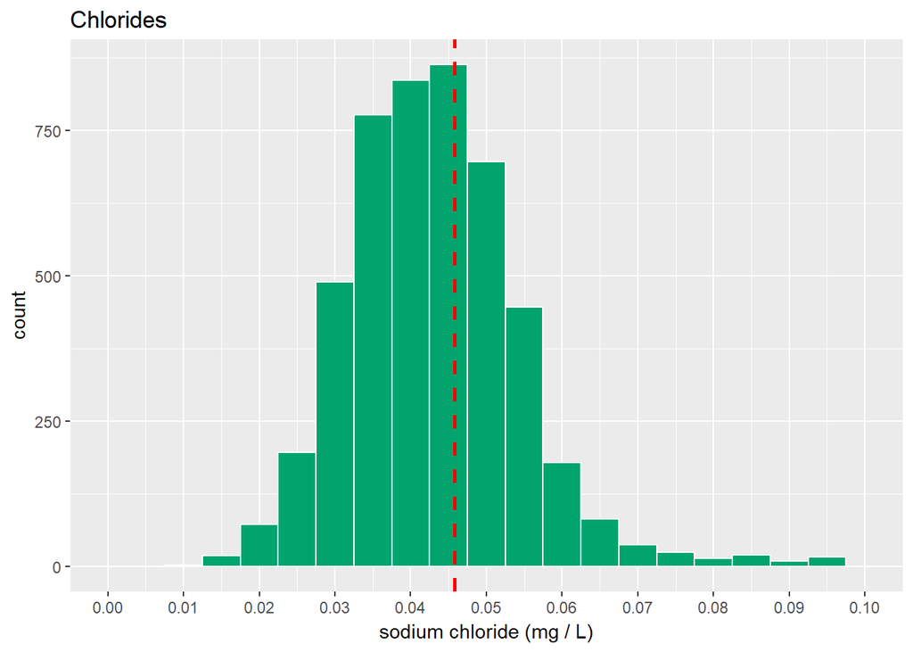

### Sulphur Dioxide

**Free sulfur dioxide** is the free form of SO2 exists in equilibrium between molecular SO2 (as a dissolved gas) and bisulfite ion; it prevents microbial growth and the oxidation of wine. The chemical count in the sample follows a very good looking normal, sligtly right-skewed distribution, with some outliers, wines have 35.31 mg/L of the SO2 on average. The data has a wide spred of 2 - 289 mg/L.

```
##    Min. 1st Qu.  Median    Mean 3rd Qu.    Max.
##    2.00   23.00   34.00   35.31   46.00  289.00
```

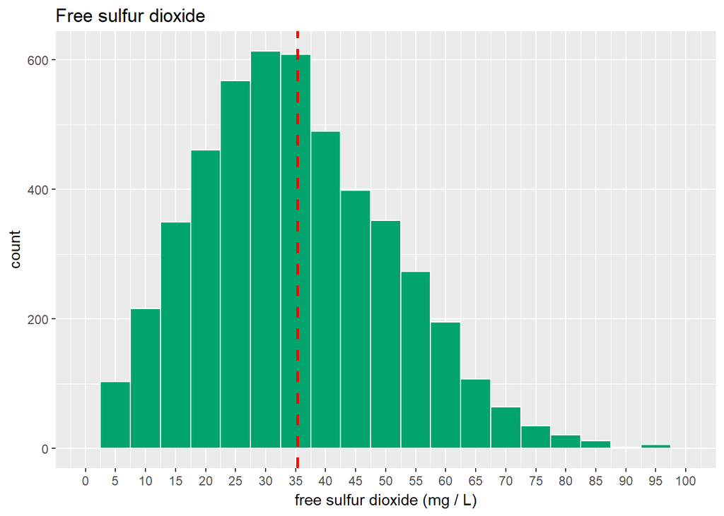

**Total sulfur dioxide** is the amount of free and bound forms of SO2; in low concentrations, SO2 is mostly undetectable in wine, but at free SO2 concentrations over 50 ppm, SO2 becomes evident in the nose and taste of wine. In this sample data is normaly distributed with mean amount of SO2 at 138.4 mg/L. The data has an even wider range of 9 - 440 mg/L, with majority of data between 70 and 210 mg/L there are many outliers which were trimmed for a better representation.

```
##    Min. 1st Qu.  Median    Mean 3rd Qu.    Max.
##     9.0   108.0   134.0   138.4   167.0   440.0
```

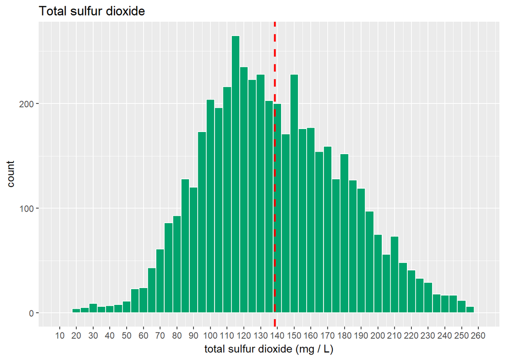

### Density

Density has a mean of 0.994 g/L, and some outliers over 1 g/L, suggesting there are some wines in the sample which are more dence than water. In general liquids containing alcohol are less dence than water. There are a few outliers which were trimmed from the x axis.

```
##    Min. 1st Qu.  Median    Mean 3rd Qu.    Max.
##  0.9871  0.9917  0.9937  0.9940  0.9961  1.0390
```

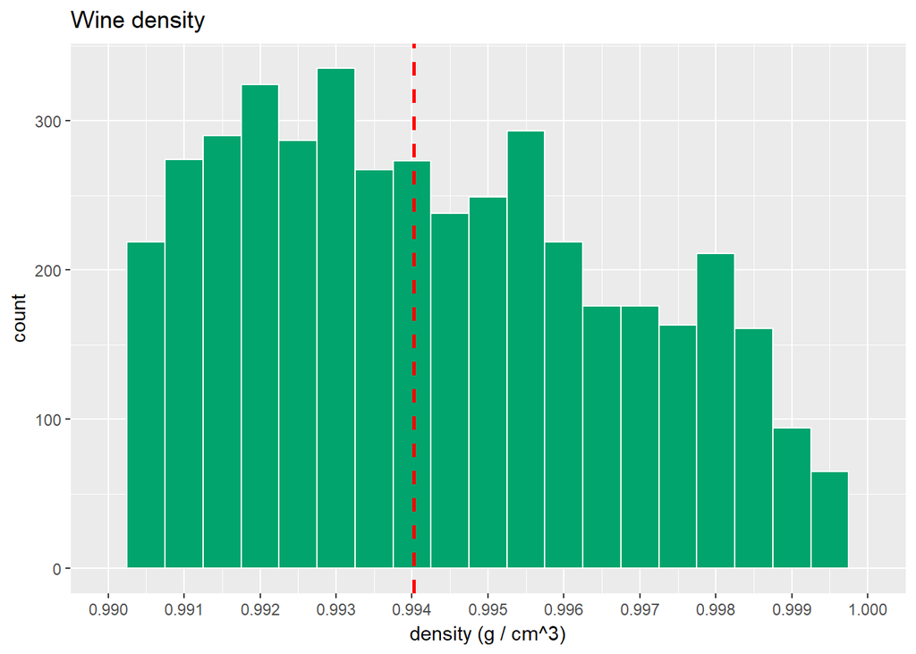

### pH

pH describes how acidic or basic a wine is on a scale from 0 (very acidic) to 14 (very basic); most wines are between 3-4 on the pH scale. The distribution appears normal, spanning between 2.72 and 3.82, with mean acidity at 3.188. All wines in the sample fall within a normal pH level for white wine, which is generaly lean towards acidic side of pH level more than other types of wines.

```
##    Min. 1st Qu.  Median    Mean 3rd Qu.    Max.
##   2.720   3.090   3.180   3.188   3.280   3.820
```

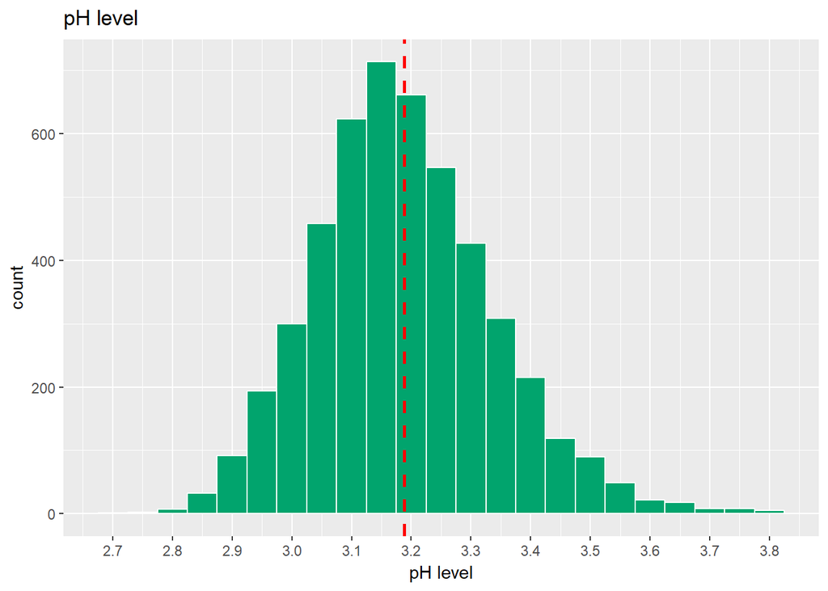

### Alcohol

The mean of alcohol contant in the wine set is 10.51% and the majority of values fall between 9% to 11%. Alcohold is considered another very important aspect of wine tasting, and thus it is expected to affect the quality rating.

```
##    Min. 1st Qu.  Median    Mean 3rd Qu.    Max.
##    8.00    9.50   10.40   10.51   11.40   14.20
```

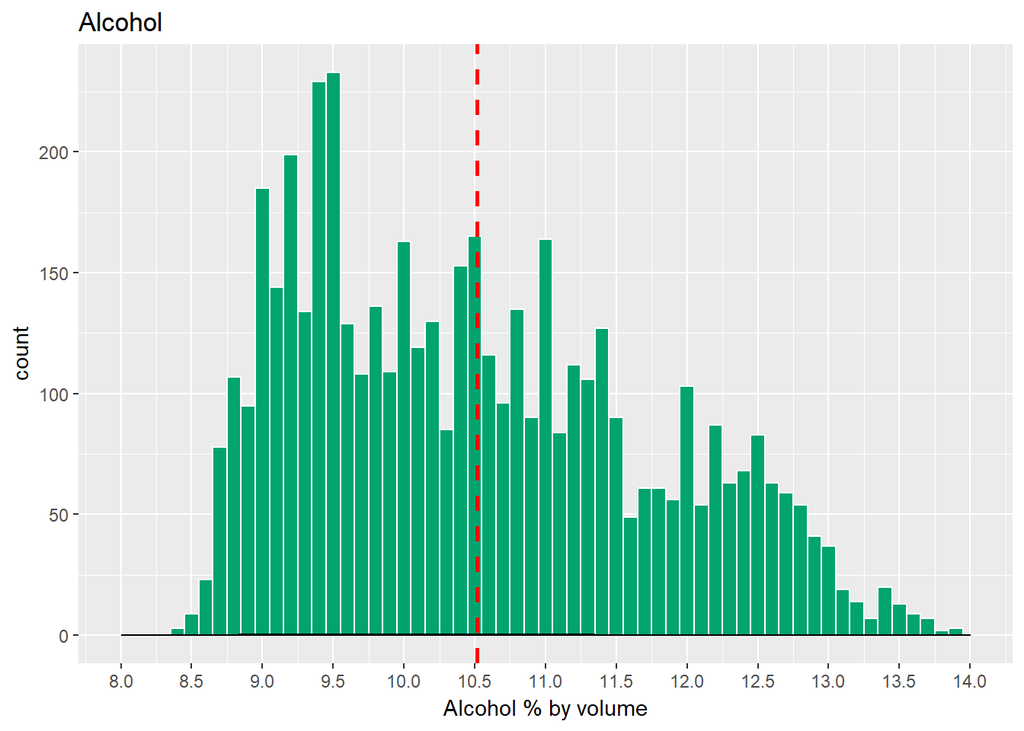

### Quality Score

Each of at least 3 sommelier - subject-matter expert on wine - graded the wine quality between 0 (very bad) and 10 (very excellent). The histogram demonstrates the distribution of Wine quality ratings. The distribution appears normal spanning between 3 and 9, so there are no very bad or very excelent wines. The median is 6.

[output not shown]

```
##
##    3    4    5    6    7    8    9
##   20  163 1457 2198  880  175    5
```

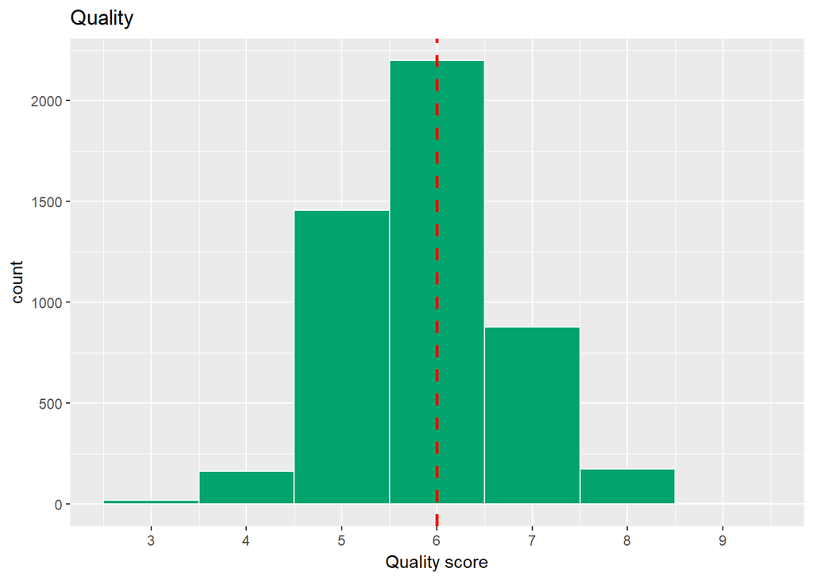

# Univariate Analysis

Exploring the dataset following findings: The percentage of alcohol in wine bounds from 8 and 14.20 percent. About 75% of the wines have a residual sugar value below 10 grams/liter (over 35 are considered sweet). Some wines have not citric acid. Mean quality is 5.878, max and min quality are 9 and 3 respectively.

**Structure of the dataset** - 4,898 white wine specimens - 11 variables defining the chemical properties of each wine. - 1 output variable - a rating between 0 (very bad) and 10 (very excellent), provided by expert wine tasters.

**Main features of interest** The main feature of the data set is the output quality rating, all the chamical properties of wines will be mesured against the quality rating, to determine a correlation. Since the rating is given subjectively by the experts’ tasting, other features of interest are: alcohol, residual sugar (RS) and density.

**Further steps and modifications** I will create category labels of acidity and sweetness, mainly for labeling purposes during the multivariate analysis. I will also remove the wine index ‘X’, which is not nessesary for this analysis.

# Bivariate Plots Section

### Correlation Matrix

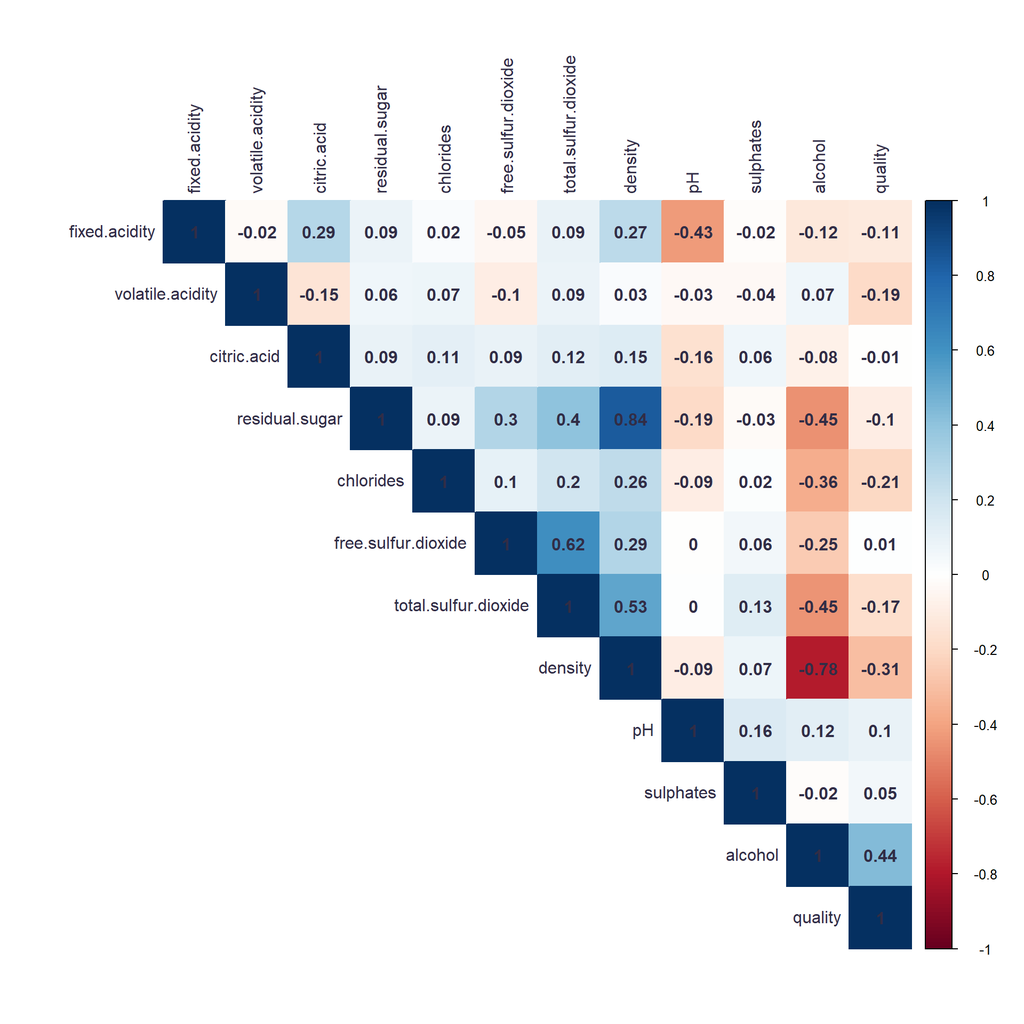

Looking at other variables: * Density and Residual sugar have the stronges positive relationship of 0.84. * Density and Alcohol have the strongest negative correlation of - 0.78, which can be expected. * Density and Total SO2 have moderate correlation of 0.53. * Alcohol has moderate negative correlations with Residual sugar(-0.45), Total SO2 (-0.45) and Chlorides (-0.36). * Fixed Acidity has a moderate negative correlation with pH level of -0.43, which is expected as pH defines how basic or acidic a substance is.

In order to investigate Bivariate correlation, I have converted quality into a categorical value.

### Quality and Alcohol content

These two variables have a moderate positive correlation of 0.44, in the given sample alcohol has the biggest correlation coefficient with quality rating and vice versa.  
The graph below demonstrates distribution of alcohol content in each quality rating group. The relationship appears non-linear, quality group 5 has a median of alcohol content is 9.5%, gradually rising up to 12% in the age group of 8. Higher alcohol content in quality groups 4 and 3 may be explained by an influence from other chemical properties.

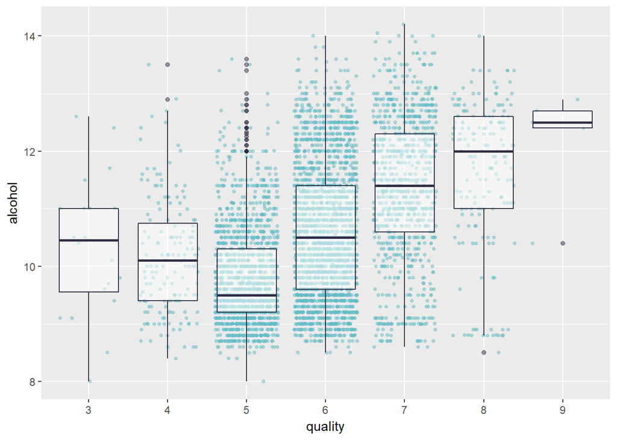

```
## wq$quality: 3
##    Min. 1st Qu.  Median    Mean 3rd Qu.    Max.
##    8.00    9.55   10.45   10.35   11.00   12.60
## --------------------------------------------------------
## wq$quality: 4
##    Min. 1st Qu.  Median    Mean 3rd Qu.    Max.
##    8.40    9.40   10.10   10.15   10.75   13.50
## --------------------------------------------------------
## wq$quality: 5
##    Min. 1st Qu.  Median    Mean 3rd Qu.    Max.
##   8.000   9.200   9.500   9.809  10.300  13.600
## --------------------------------------------------------
## wq$quality: 6
##    Min. 1st Qu.  Median    Mean 3rd Qu.    Max.
##    8.50    9.60   10.50   10.58   11.40   14.00
## --------------------------------------------------------
## wq$quality: 7
##    Min. 1st Qu.  Median    Mean 3rd Qu.    Max.
##    8.60   10.60   11.40   11.37   12.30   14.20
## --------------------------------------------------------
## wq$quality: 8
##    Min. 1st Qu.  Median    Mean 3rd Qu.    Max.
##    8.50   11.00   12.00   11.64   12.60   14.00
## --------------------------------------------------------
## wq$quality: 9
##    Min. 1st Qu.  Median    Mean 3rd Qu.    Max.
##   10.40   12.40   12.50   12.18   12.70   12.90
```

### Quality and density

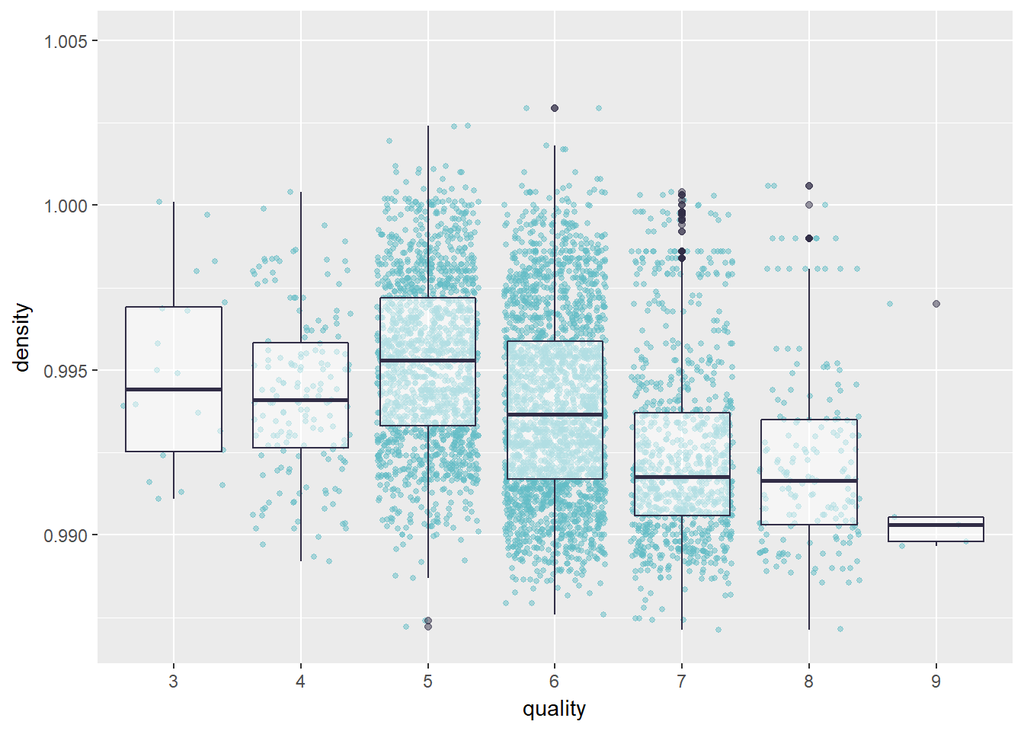

```
## wq$quality: 3
##    Min. 1st Qu.  Median    Mean 3rd Qu.    Max.
##  0.9911  0.9925  0.9944  0.9949  0.9969  1.0001
## --------------------------------------------------------
## wq$quality: 4
##    Min. 1st Qu.  Median    Mean 3rd Qu.    Max.
##  0.9892  0.9926  0.9941  0.9943  0.9958  1.0004
## --------------------------------------------------------
## wq$quality: 5
##    Min. 1st Qu.  Median    Mean 3rd Qu.    Max.
##  0.9872  0.9933  0.9953  0.9953  0.9972  1.0024
## --------------------------------------------------------
## wq$quality: 6
##    Min. 1st Qu.  Median    Mean 3rd Qu.    Max.
##  0.9876  0.9917  0.9937  0.9940  0.9959  1.0390
## --------------------------------------------------------
## wq$quality: 7
##    Min. 1st Qu.  Median    Mean 3rd Qu.    Max.
##  0.9871  0.9906  0.9918  0.9925  0.9937  1.0004
## --------------------------------------------------------
## wq$quality: 8
##    Min. 1st Qu.  Median    Mean 3rd Qu.    Max.
##  0.9871  0.9903  0.9916  0.9922  0.9935  1.0006
## --------------------------------------------------------
## wq$quality: 9
##    Min. 1st Qu.  Median    Mean 3rd Qu.    Max.
##  0.9897  0.9898  0.9903  0.9915  0.9906  0.9970
```

### Quality and volatile Acidity

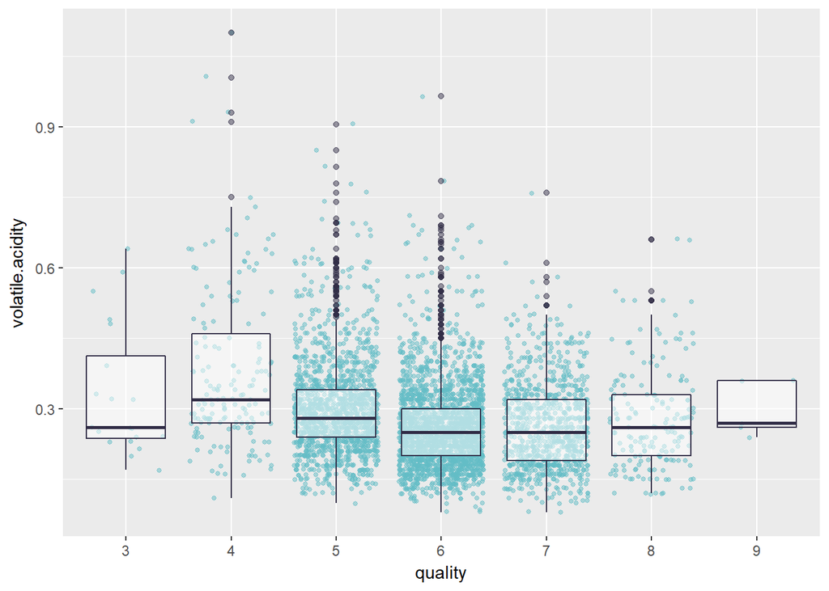

### Residual Sugar and Density

The residual sugar and density have the highest positive corellation in the data set. Residual Sugar, although not very noticeable in wine by the inexperienced taster, affects the density of the liquid.

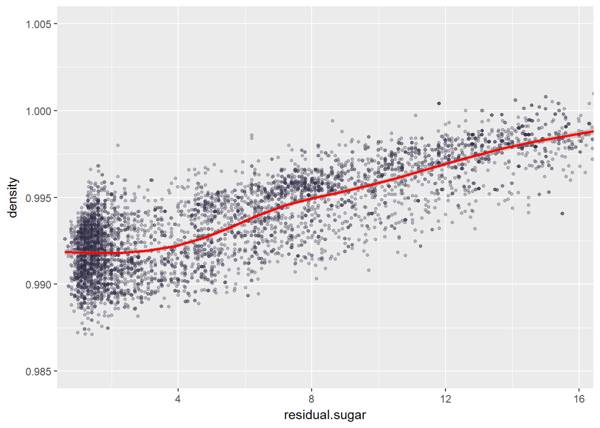

### Alcohol and Density

In terms of alcohol and density, the negative correlation is quite strong - 0.78. It appears moderately linear with only small fluctuations. This relationship is reinforced by a common fact that higher content of alcohol in drinks make it [less dence than water](http://chemistry.elmhurst.edu/vchembook/124densityliq.html).

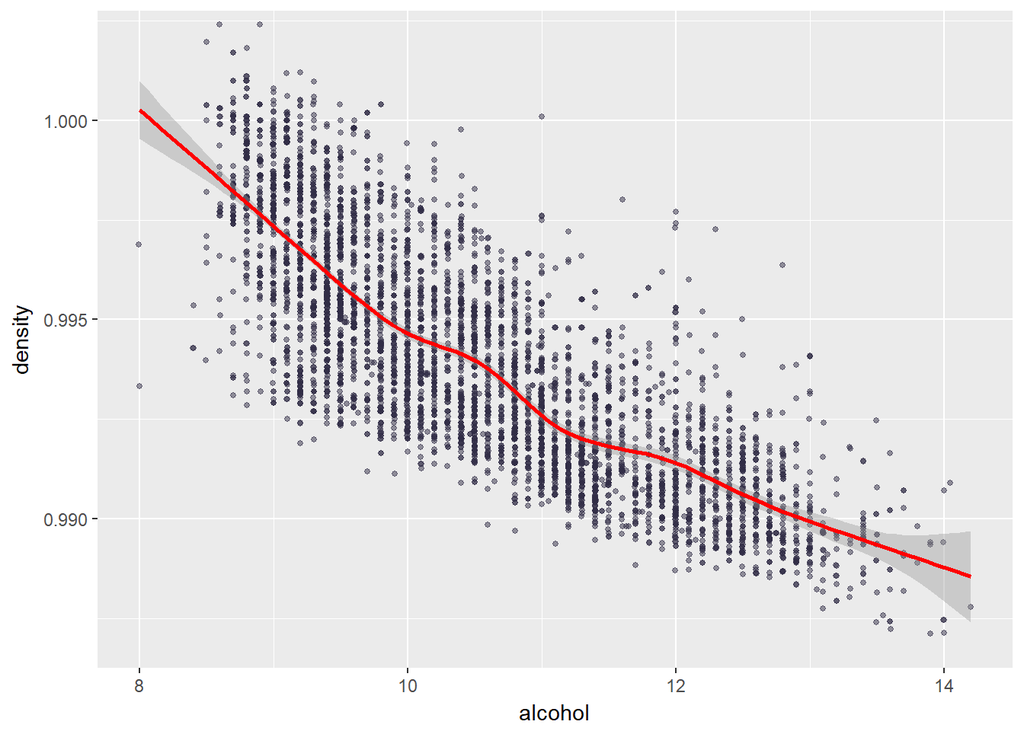

### Residual Sugar and Alcohol

Looking at the plots above it is interesting to see the relationship between the Residual Sugat and Alcohol. According to the correlation matrix they have a moderate negative correlation of -0.45. It does not appear linear, there is a big hill at the begining of the plot which may be affecred be an increased number of samples. Overall there is a pattern that alcohol content gradually falls with increasing Residual sugar content.

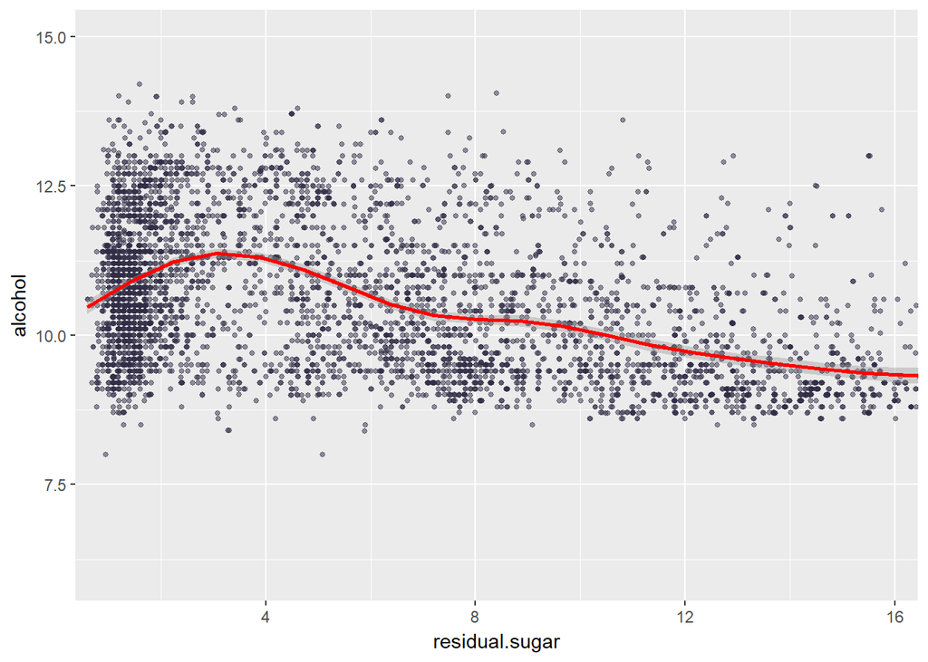

### Density and Total Sufur Dioxide.

Density and Total SO2 have moderate amd dence correlation of 0.53. The correlation isn’t linear, but the plot illustrates that with a higher SO2 content the wines reach the density similar to water.

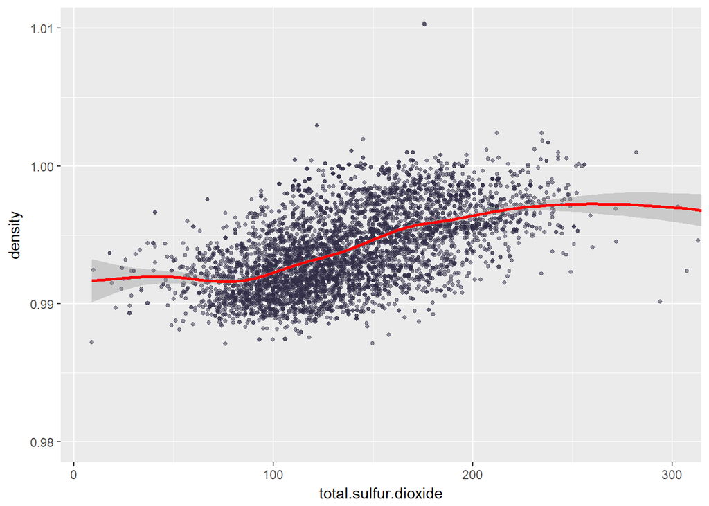

### Alcohol and Total sulphur dioxide

These two variables have a negative correlation of -0.45, it is closely a linear relationship. The amount of SO2 drops gradually as the Alcohol concentration increases.

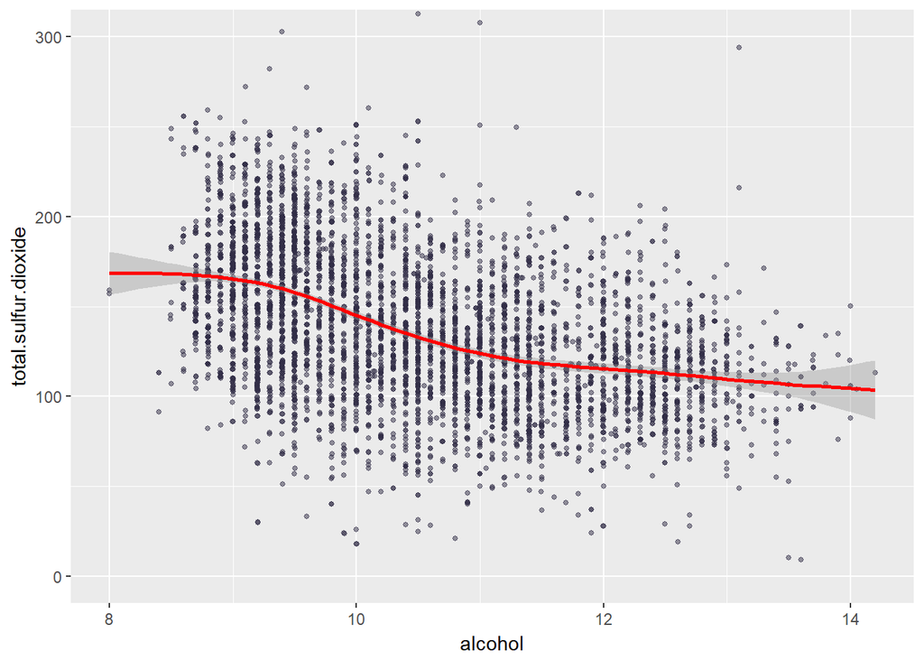

### Fixed Acidity and pH

This relationship illustrates how more acidic wines are based on a lower (acidic) part of pH scale.

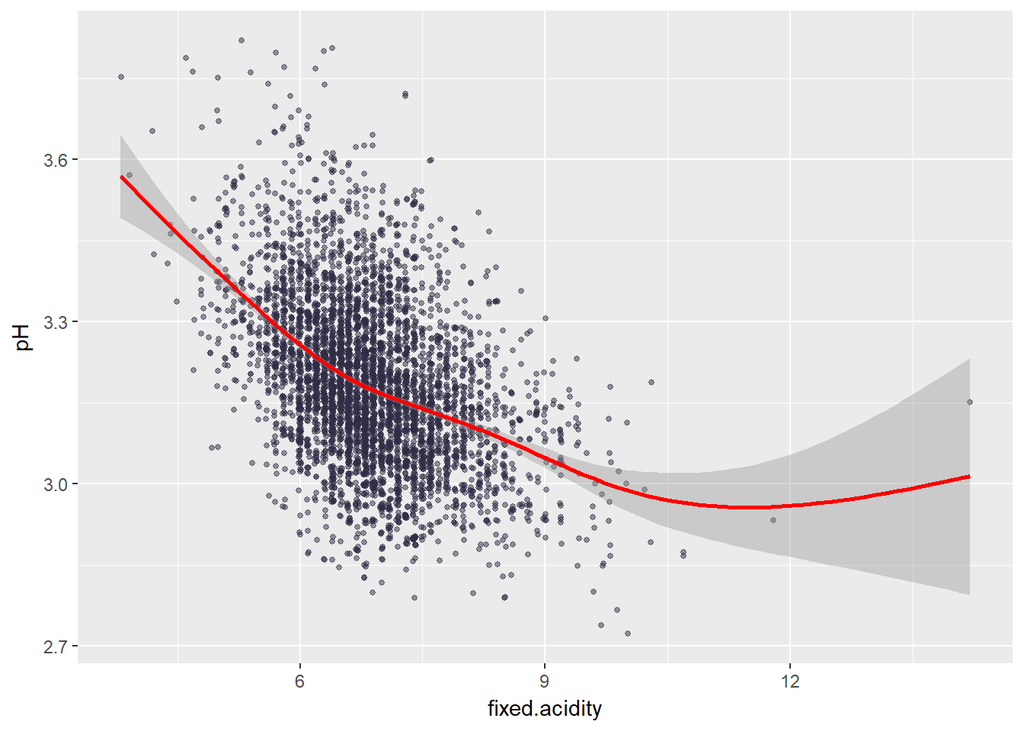

# Bivariate Analysis

### Relationships observed

Overall it was a bit dissappointing to see that main taste qualities of wine, such as acidity and sweetness have a low effect on quality. The highest positive correlation of quality rating appears to be with alcohol.

Not all correlations are confirmed when plotted.

# Multivariate Plots Section

### Quality rating by Alcohol and residual sugar

The following graph demonstrates very well, how alcohol content affects quality rating, higher alcohol content is observed in wines rated 6 and above, the mean alcohol percentage of wines rated 6 is 10.58%, while in wines rated 8 the alcohol is at 11.64%.  
Further more the plot confirms residual sugar is prevalent in wines with smaller alcohol content. The highest mean RS of 7.335 g/L is in wines rated 5, while wines which received rating of 8 contain 5.671 g/L of residual sugar on average.

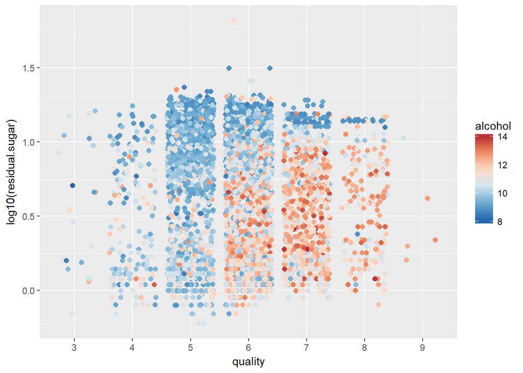

### Residual Sugar and Alcohol by Density

The following graph represent relationship of Alcohol and Residual Sugar, there is no linear relationship, but the graph illustrates well how density rises with the increase of Residual Sugar content.

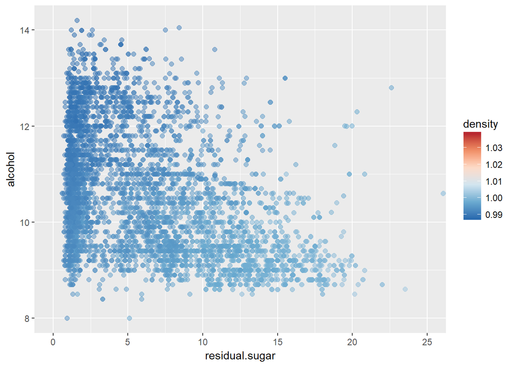

### Sweetness categories

```
##   BONE DRY        DRY    OFF-DRY      SWEET VERY SWEET
##         77       3610       1210          1          0
```

### Quality rating by Density and Sweetness categories

The distribution belowshows that the very dry wines are mostly not so populat, Dry wines tend to get a wide spread of quality ratings, with many getting high ratings. Sweetter wines mostly receive medium ratings of 5 and 6.

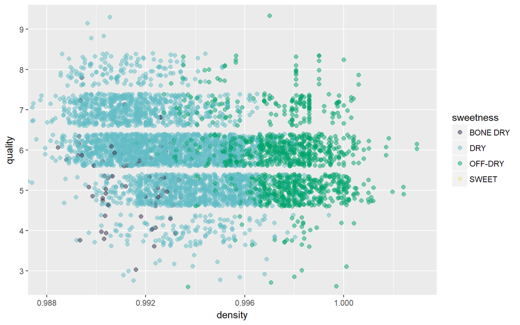

### Alcohol % and Quality by Sweetness Category

The plot below demonstrated distribution of alcohol and quality, with sweetness categories. Bone-dry (very dry) wines, though few in this data set, are well spread, but do not tend to get high ratings. Dry wines have higher alcohol content than slightly sweeter ones with medians of 10.7 and 9.3 respectively. This reinforces the fact that during the wine tasting Alcohol and Residual Sugar are competting qualities, which over power each other.

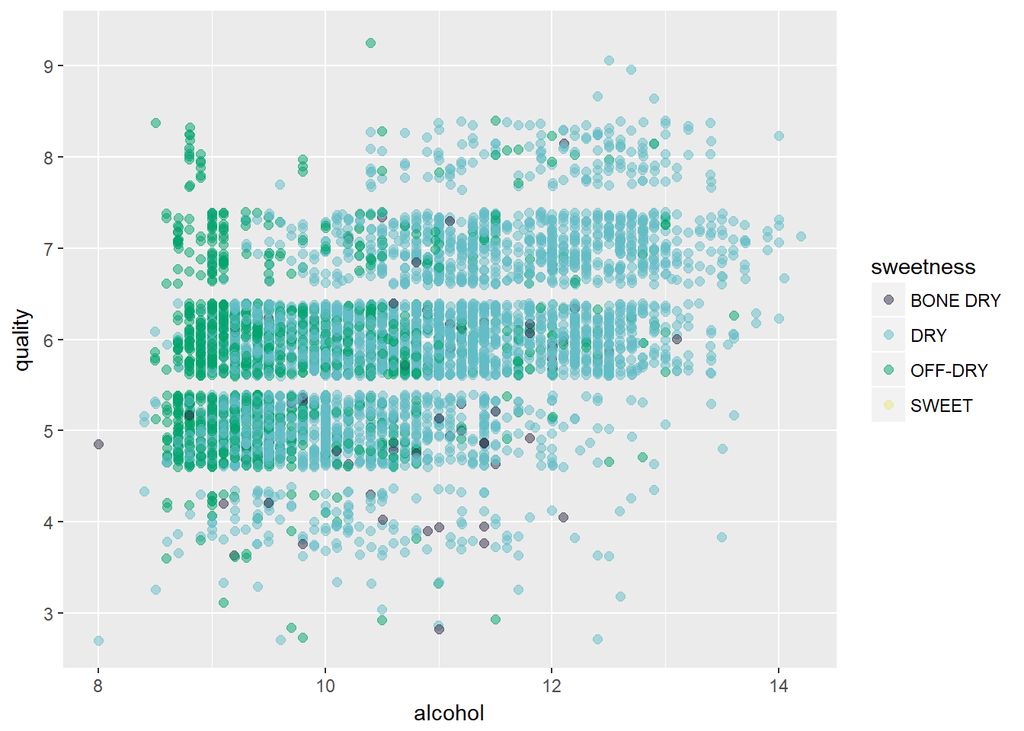

```
## wq$sweetness: BONE DRY
##    Min. 1st Qu.  Median    Mean 3rd Qu.    Max.
##    8.00    9.80   10.60   10.58   11.40   13.10
## --------------------------------------------------------
## wq$sweetness: DRY
##    Min. 1st Qu.  Median    Mean 3rd Qu.    Max.
##    8.00    9.80   10.70   10.82   11.70   14.20
## --------------------------------------------------------
## wq$sweetness: OFF-DRY
##    Min. 1st Qu.  Median    Mean 3rd Qu.    Max.
##   8.500   9.000   9.300   9.599   9.975  13.600
## --------------------------------------------------------
## wq$sweetness: SWEET
##    Min. 1st Qu.  Median    Mean 3rd Qu.    Max.
##    11.7    11.7    11.7    11.7    11.7    11.7
## --------------------------------------------------------
## wq$sweetness: VERY SWEET
## NULL
```

Below is a better representation of Alcohol and Residual Sugar showing that Off-Dry (sweeter) wines have considerably less alcohol compared to other categories.

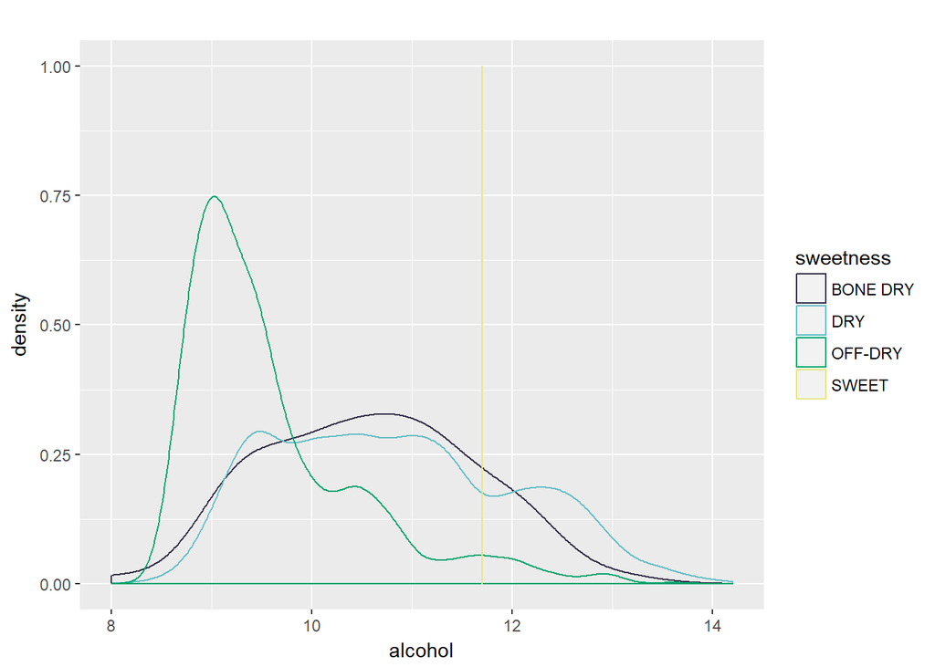

# Multivariate Analysis

# Final Plots and Summary

### Plot One

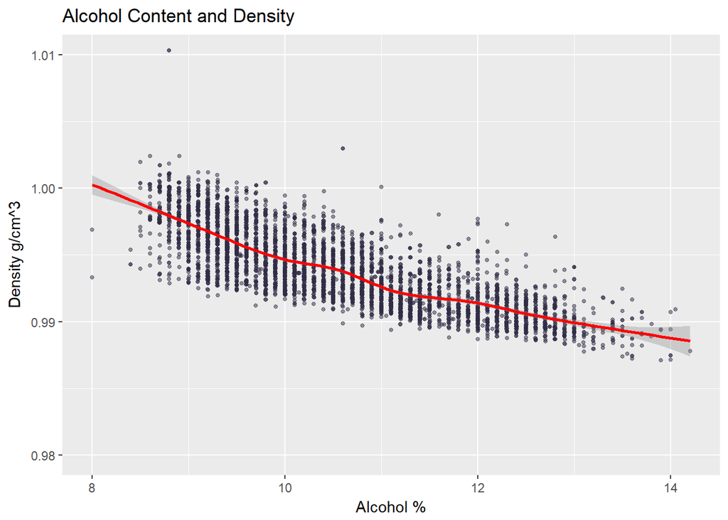

### Description One

I found it very interesting that the Density of white wine drops steadily with the increase of alcohol content. The graph shows very well this relationship.

### Plot Two

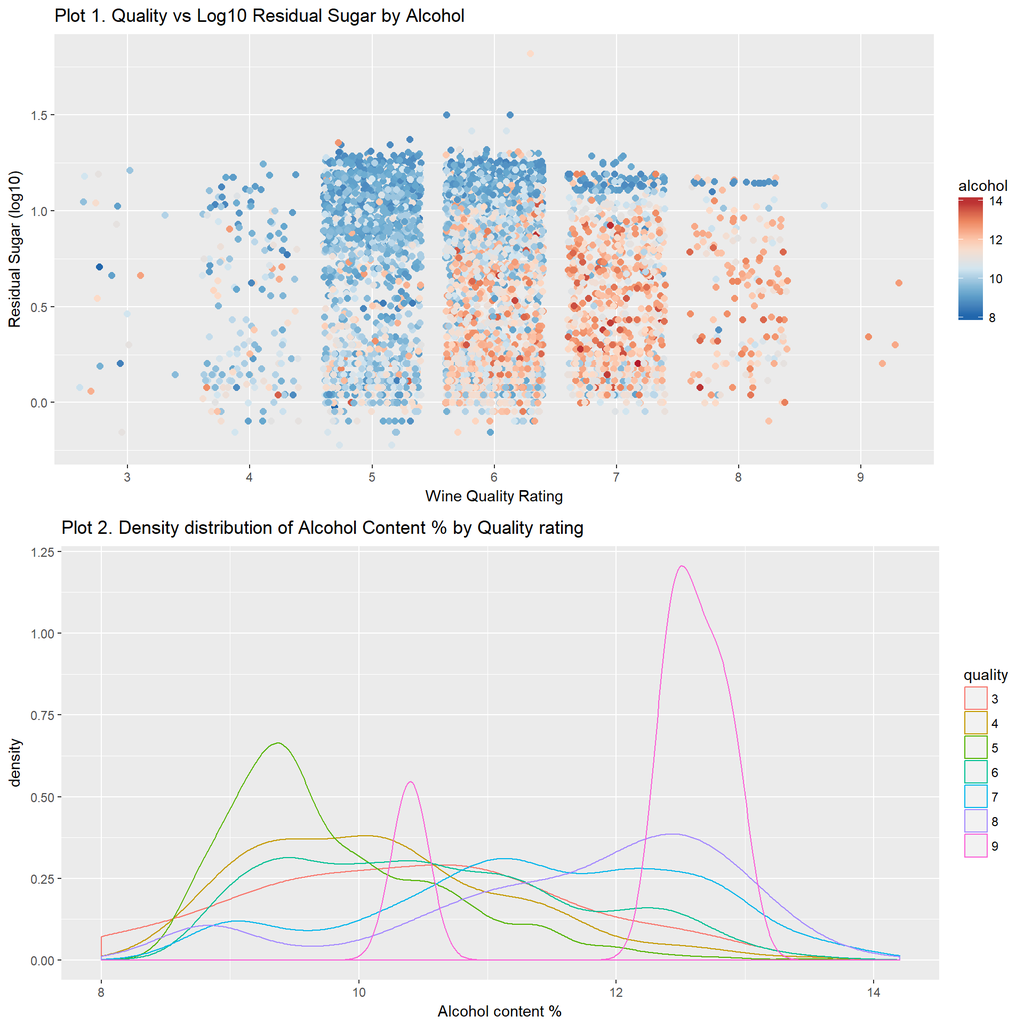

### Description Two

**Plot 1**: There is an interesting relationship between Residual Sugar, Alcohol and Quality rating, as higher alcohol content is observed in wines rated 6 and above. Further more the plot confirms residual sugar is prevalent in wines with smaller alcohol content. **Plot2**: The following graphs shows density with which alcohol is distributed according to quality rating. This reinforces a positive correlation as in boxplots above, with lower alcohol levels scorring 5 and 6 ratings, and higher alcohol content scorring 7 and 8 ratings.

### Plot Three

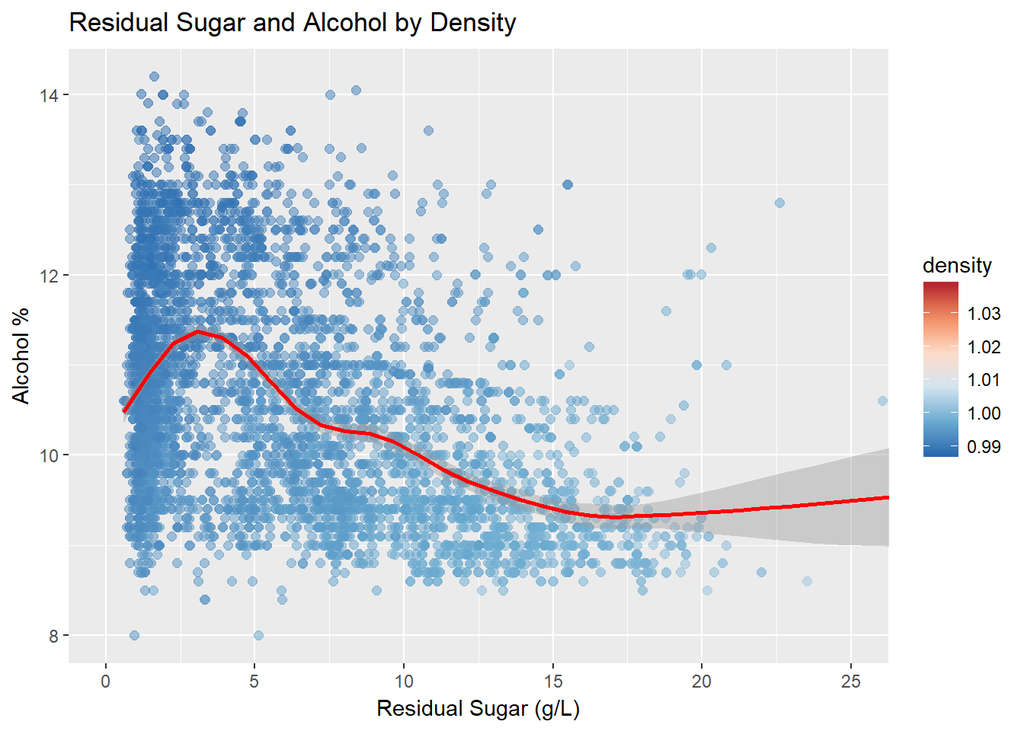

### Description Three

The plot above represents relationship of Alcohol and Residual Sugar, there is no linear relationship, but the graph illustrates well how density rises with the increase of Residual Sugar content and how Alcohol content is much less in sweeter wines.

# Reflection

This clean data set has enabled by to explore and learn about wine phisiochemical properties, as well as find some unexpected relationships.  
Initially I assumed that such aspects as Acidity, Sweetness and Tanin were main features of wine tasting, but instead it was revealed that white wine with higher Alcohol content tend to score higher. Furthermore, Alcohol is an active characteristic compared to other chemicals as it has the ability to mask unpleasant smells or excess volatile acidity during tasting, and instead will highlight dryness (sourness) of a wine. This is why cheaper wines usually have higher alcohol level.

It is important to note that findings in this analysis are strictly subjective to the data set provided, correlation does not imply causation. And the relationships found in this analisys may be influenced by other factors.

The quality rating given by a somelier is based on more than the phisiochemical properties of the wine. For instance, period and conditions of wine aging, grape type and tasting conditions are all very important aspects of an acurate quality rating of wines. None of these aspects were given in an initial data set due to confidentiality. A fuller data set with more variables would have enabled to investigate if wines with different origins have different chemical properties. Or perhaps if wine preparation process affects it’s final quality.

Furthermore, A bigger sample would have enabled to have more category counts, and perhaps it would have improved some bias in this analisys.

### Resources

- [Wine characteristics](http://winefolly.com/review/wine-characteristics/)
- [Importance of taste in wine](http://winefolly.com/review/how-to-taste-wine-develop-palate/)
- [Colour palete for graphs and intro to wine characteristics](http://www.vinhoverde.pt/en/)
- All code in this codument was based on the examples from Udacity Course materials, some variations for the plot appearance (e.g. color schemes) were based on suggestions from the Udacity Student forum.